# Investigations on Human Chromosome 21

**朱瑾煜 Zhu Jinyu, 2000012180**

## 1 Objectives

- Obtain biological information (including length, number of genes, distribution of transcripts per gene, etc.) from the sequence data and the annotation of human Chromosome 21.
- Compare Chromosome 21 with other human chromosomes.
- Practice using HPC and basic commands of Linux/UNIX.

## 2 Introduction

Chromosome 21 is the smallest chromosome in human genome, containing about 48 million base pairs and 215 protein coding genes.[^1] Chromosome 21 is essential for human and is related to some important genetic diseases, such as Down’s syndrome due to an extra copy of Chromosome 21. In this project, we explore the sequence and annotation of Chromosome 21 to better undestand its biological role and function, and to practice using HPC and Linux/UNIX at the same time.

## 3 Methods and materials

### 3.1 Linux/UNIX systems

The following Linux/UNIX systems are applied to this project.

- High performance computing platform on http://www.aais.pku.edu.cn/clshpc/cqbsys/, `CentOS Linux release 7.6.1810 (Core)`
- Personal lighthouse server on [Tencent Cloud](https://cloud.tencent.com/), `CentOS Linux release 7.9.2009 (Core)`
- Personal MacBook Pro, `macOS Monterey 12.0.1` (macOS is a variety of UNIX, quite similar to Linux)

Most of the data is downloaded using `scp` command from HPC, and most of the work is done on personal server and MacBook Pro, **since the HPC cannot write anything**.

### 3.2 R Language

The version of R Language in this project is `R 4.1.2`. Packages `tidyverse` and `ggplot2` is also applied.

### 3.3 Data

The data file names and their sources are as follows:

- `chr21.fa`, the sequence file of Chromosome 21 in `fasta` format, unknown source (on HPC)
- `annotation.gtf`, the annotation file of Chromosome 21 in `gtf` format, from Ensembl (on HPC)
- `wholeGenome.gtf`, the annotation file of whole human genome (including mitochondrial DNA, MT) in `gtf` format, from Ensembl (manually downloaded from http://ftp.ensembl.org/pub/current_gtf/homo_sapiens/Homo_sapiens.GRCh38.105.chr.gtf.gz)

## 4 Results

### 4.1 Length of Chromosome 21

Use the following command to count bases in the sequence file `chr21.fa`.

```bash
# base count
cat chr21.fa | wc -c
```

The result is `47644190 chr21.fa`, meaning there is 47,644,190 characters in the `fasta` file. Considering the file is leading by a prompt sequence `>chr21`, this 6 characters should be subtracted from the result. Therefore, there is altogether 47,644,184 base pairs in Chromosome 21; i.e., the length of Chromosome 21 is 47,644,184 bp.

We noticed that there are lots of `N`s at the beginning and the end of the sequence. The following command tells that there are actually 6,755,800 `N`s. The letter `N` represents any of the four bases `A`, `T`, `G` and `C`.

```bash
# N count
cat chr21.fa | grep 'N' | wc -c
```

### 4.2 Number of different features on Chromosome 21

```bash
# obtain a list of different kinds of features (the first 5 lines are descriptions to the file, beginning with #, which are removed by `tail +6`)
cat annotation.gtf | cut -f 3 | tail +6 | sort -u > category.txt

# obtain the number of each feature
cat category.txt | while read line
do
    echo $(cat annotation.gtf | cut -f 3 | tail +6 | grep $line | wc -w)'\t'$line's' >> category_results.txt
done
```

The results are in `category.txt` and `category_results.txt`:

```
category.txt
CDS
UTR
exon
gene
start_codon
stop_codon
transcript

category_results.txt
7709    CDSs
2896    UTRs
16659   exons
872 genes
857 start_codons
813 stop_codons
2925    transcripts
```

There are 7,709 CDSs (coding sequences), 2,896 UTRs (untranslated regions), 16,659 exons, 872 genes, 857 start codons, 813 stop codons, and 2925 different transcripts on Chromosome 21.

### 4.3 Gene ID

The following command lists the first 6 gene IDs in the annotation file.

```bash
# List gene ID
cat annotation.gtf | cut -f 3,9 | tail +6 | sed 's/;/\t/g' | cut -f 2 | head 6
```

```
gene_id "ENSG00000279493.1"
gene_id "ENSG00000279493.1"
gene_id "ENSG00000279493.1"
gene_id "ENSG00000279493.1"
gene_id "ENSG00000279493.1"
gene_id "ENSG00000279493.1"
```

### 4.4 Numbers of transcripts per gene

A list of different (without repeats) gene IDs and a list of transcripts with their gene ID are obtained and saved in `geneID.txt` and `transcripts.txt` respectively.

```bash
# list gene ID (unique sorted)
cat annotation.gtf | cut -f 3,9 | tail +6 | sed 's/;/\t/g' | cut -f 2 | sort -u > geneID.txt

# list transcripts with gene ID
cat annotation.gtf | cut -f 3,9 | tail +6 | sed 's/;/\t/g' | awk -F '\t' '$1 == "transcript" {print $2}' > transcripts.txt
```

Then, the following commands are applied to obtain how many transcripts each gene has.

```bash
# count transcripts per gene ID
cat geneID.txt | while read line
do
    echo $line'\t'$(cat annotation.gtf | cut -f 3,9 | tail +6 | sed 's/;/\t/g' | awk -F '\t' '$1 == "transcript" {print $1, $2}' | grep $line | wc -l) >> geneID_count.txt
done
```

Here we display the first 6 lines of the output `geneID_count.txt`: (872 lines in total, since there are altogether 872 genes, according to Section 4.2)

```
gene_id "ENSG00000141956.13"     16
gene_id "ENSG00000141959.17"     12
gene_id "ENSG00000142149.9"  4
gene_id "ENSG00000142156.14"     7
gene_id "ENSG00000142166.13"     7
gene_id "ENSG00000142168.14"     4
```

and draw a histogram showing the distribution of transcript number per gene using R.

```r
library(tidyverse)
```

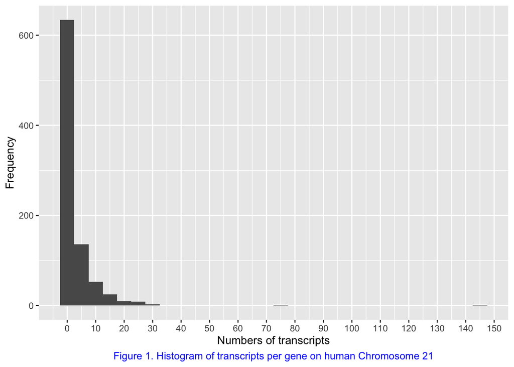

```r
library(ggplot2)

transcripts <- read.table("/Users/jinyuzhu/Desktop/lib_data/geneID_count.txt", sep = "\t")

names(transcripts) <- c("Gene","Frequency")

ggplot(data = transcripts, mapping = aes(x = Frequency)) + geom_histogram(binwidth = 5) + scale_x_continuous(breaks = seq(0,150,10)) + labs(caption = "Figure 1. Histogram of transcripts per gene on human Chromosome 21", x = "Numbers of transcripts", y = "Frequency") + theme(plot.caption=element_text(size=10,hjust=0.5,color="blue"))
```

### 4.5 lncRNA

lncRNAs, or long non-coding RNAs (long ncRNAs, lncRNA), are commonly defined as RNAs with more than 200 nucleotides that are not translated into protein, including intergenic lincRNAs, intronic ncRNAs, and sense and antisense lncRNAs.[^2]

In order to realize how many lncRNA genes and transcripts Chromosome 21 has, the following commands are applied:

```bash
# number of lncRNA genes and transripts
cat annotation.gtf | cut -f 3,9 | tail +6 | sed 's/;/\t/g' | awk -F '\t' '$1 == "gene" {print $3}' | grep 'lncRNA' | wc -l
cat annotation.gtf | cut -f 3,9 | tail +6 | sed 's/;/\t/g' | awk -F '\t' '$1 == "transcript" {print $4}' | grep 'lncRNA' | wc -l
```

The results show that there are 330 lncRNA genes and 1,039 lncRNA transcripts.

Additionally, we wanted to find out whether there is a gene encoding both proteins and lncRNAs. We tried to simply look at the `gene_type` description by the following commands, but that was not helpful.

```bash
## gene_type description does not contain two functions at the same time
cat annotation.gtf | cut -f 3,9 | tail +6 | sed 's/;/\t/g' | awk -F '\t' '$1 == "gene" {print $3}' | sort -u
```

The descriptions do not contain two functions at the same time – in other words, there is not a `gene_type` like `"protein_coding_and_lncRNA"`.

```
 gene_type "IG_V_gene"
 gene_type "TEC"
 gene_type "lncRNA"
 gene_type "miRNA"
 gene_type "misc_RNA"
 gene_type "processed_pseudogene"
 gene_type "protein_coding"
 gene_type "pseudogene"
 gene_type "rRNA"
 gene_type "rRNA_pseudogene"
 gene_type "snRNA"
 gene_type "snoRNA"
 gene_type "transcribed_processed_pseudogene"
 gene_type "transcribed_unprocessed_pseudogene"
 gene_type "unprocessed_pseudogene"
```

However, we found that some transcripts are lncRNAs, but they belong to protein coding genes, like the following one:

```
chr21   HAVANA  transcript  5120634 5124868 .   -   .   gene_id "ENSG00000280071.4"; transcript_id "ENST00000624748.2"; gene_type "protein_coding"; gene_name "GATD3B"; transcript_type "lncRNA"; transcript_name "GATD3B-209"; level 2; transcript_support_level "3"; hgnc_id "HGNC:53816"; havana_gene "OT…
```

The following commands tell that there are 335 lncRNA transcripts belonging to protein coding genes. Therefore, we draw a conclusion that a gene can encode proteins and lncRNAs at the same time.

```bash
cat annotation.gtf | cut -f 3,9 | tail +6 | sed 's/;/\t/g' | awk -F '\t' '$1 == "transcript" && $4 == " gene_type \"protein_coding\"" && $6 == " transcript_type \"lncRNA\"" {print}' | wc -l
```

### 4.6 Overview to the whole genome

Use manually downloaded `wholeGenome.gtf`, and the following commands to obtain features of the whole genome:

```bash
cat wholeGenome.gtf | cut -f 3 | tail +6 | sort -u > category_WG.txt
cat category_WG.txt | while read line
do
    echo $(cat wholeGenome.gtf | cut -f 3 | tail +6 | grep $line | wc -w)'\t'$line's' >> category_results_WG.txt
done
```

The file `category_WG.txt` shows the following types of features:

```
CDS
Selenocysteine
exon
five_prime_utr
gene
start_codon
stop_codon
three_prime_utr
transcript
```

and `category_results_WG.txt` shows the number of each type of features.

```
839388  CDSs
119 Selenocysteines
1551825 exons
166120  five_prime_utrs
61487   genes
94107   start_codons
87624   stop_codons
190559  three_prime_utrs
244766  transcripts
```

We see that there are 61,487 genes in the whole genome, and 119 codons that decides the 21th amino acid Selenocysteine, etc.

### 4.7 Comparation between Chromesome 21 with Chromosome 1

The commands are almost the same:

```bash
# Chromosome 1
cat wholeGenome.gtf | awk -F '\t' '$1 == "1" {print $0}' > chr1.gtf
## gene/CDS/exon count
cat chr1.gtf | cut -f 3 | tail +6 | sort -u > category1.txt
cat category1.txt | while read line
do
    echo $(cat chr1.gtf | cut -f 3 | tail +6 | grep $line | wc -w)'\t'$line's' >> category_results_1.txt
done
```

Results in `category_results_1.txt`:

```
78665   CDSs
12  Selenocysteines
143324  exons
14466   five_prime_utrs
5556    genes
8392    start_codons
8123    stop_codons
17134   three_prime_utrs
21576   transcripts
```

According to http://asia.ensembl.org/, the length of human Chromosome 1 is 248,956,422 bp, over five times longer than Chromosome 21. And according to the results, Chromosome 1 has 5,556 genes, over six times more than Chromosome 21 (see Table 1 in Section 4.8). We make the hypothesis that the number of genes a chromosome has is proportion to the DNA length.

### 4.8 Comparation between the two versions of `gtf` annotations

Files `annotation.gtf` and `wholeGenome.gtf` are both from Ensembl, but they are slightly different. The former is an older version (2019.09), while the latter is newer (2021.08). Their 3rd rows, or the feature part are different. The feature `UTR` in `annotation.gtf` is divided into two features `five_prime_utr` (5’-UTR) and `three_prime_utr` (3’-UTR) in `wholeGenome.gtf`, and a new feature `Selenocysteine` is added, representing codons that decides Selenocysteine, a newly-discovered protein amino acid.

By the following commands, the features of Chromesome 21 in `wholeGenome.gtf` can also be obtained.

```bash
cat wholeGenome.gtf | awk -F '\t' '$1 == "21" {print $0}' > chr21.gtf
cat category_WG.txt | while read line
do
    echo $(cat chr21.gtf | cut -f 3 | tail +6 | grep $line | wc -w)'\t'$line's' >> category_results_21.txt
done
```

Results:

```
8570    CDSs
0   Selenocysteines
18341   exons
1793    five_prime_utrs
890 genes
926 start_codons
904 stop_codons
1527    three_prime_utrs
3121    transcripts
```

Here we compare the features of Chromosome 21 in `annotation.gtf`, Chromosome 21 in `wholeGenome.gtf`, and Chromosome 1 in `wholeGenome.gtf` in **Table 1**:

> **Table 1.** Comparation of the features of Chromosome 21 in `annotation.gtf`, Chromosome 21 in `wholeGenome.gtf`, and Chromosome 1 in `wholeGenome.gtf`

|  | Chr21, `annotation.gtf` | Chr21, `wholeGenome.gtf` | Chr1, `wholeGenome.gtf` |
| --- | --- | --- | --- |
| CDSs | 7,709 | 8,570 | 78,665 |
| Selenocysteines | N/A | 0 | 12 |
| Exons | 16,659 | 18,341 | 143,324 |
| UTRs (total) | 2,896 | 3,320 | 31,600 |
| 5’-UTRs | N/A | 1,793 | 14,466 |
| 3’-UTRs | N/A | 1,527 | 17,134 |
| Genes | 872 | 890 | 5,556 |
| Start codons | 857 | 926 | 8,392 |
| Stop codons | 813 | 904 | 8,123 |
| Transcripts | 2,925 | 3,121 | 21,576 |

## 5 Discussion

1. A gene may have different transcripts due to alternative splicing. Most of the genes on Chromosome 21 has only one kind of transcript, while some of them can have many transcripts (maximum is 143, `gene_id ENSG00000215386.13` ).
2. lncRNAs are essential and widely distributed in human genome. Many lncRNAs are actually transcripted from protein coding genes.
3. The number of genes on a chromosome is positively correlated to the length of chromosome.
4. Bioinformatics is an ever-changing subject, and so are bioinformatic databases. In recent years, more genes and other features are found, and even a new protein amino acid Selenocysteines is discovered. That is why the two versions of annotation files are so different.

## 6 Acknowledgement

Thanks to the instructor Fenglin Liu and teaching assistant Xinyu Yang for providing devices and giving guidance on this project. Thanks to my teammate, Xinyi Zhang for her cooperation.

## 7 Supplementary Information

All source code are avaliable on GitHub: https://github.com/jyzhu2020/bioinfo_experiment/tree/main/2_HPC.

## 8 References

[^1]: https://en.wikipedia.org/wiki/Chromosome_21
[^2]: https://en.wikipedia.org/wiki/Long_non-coding_RNA